# HeatMapPlottingOfWeeklyVLatBandSurvial

A Fischbach

May 17, 2018

## Load the data

The dat.frame df_ee was built by the ._weeklySurvival.r script, which georaphically summarized weekly survival into 1 degree latitudinal bands for all taxa, modeles across study years within each study period.

```r
  load("~/Rcode/sea-invaders/rData/week_survival_lat_taxa_model_studyPeriod.rData")
  cat(nrow(df_ee), 'rows of data read in from', length(unique(df_ee$taxa)), 'taxa', fill =T)
```

```
## 47040 rows of data read in from 49 taxa
```

```r
  glimpse(df_ee)
```

```
## Observations: 47,040
## Variables: 57
## $ Week_01        <dbl> 0.083333333, 0.568807339, 0.875000000, 0.596899...
## $ Week_02        <dbl> 0.08333333, 0.54128440, 0.87500000, 0.58914729,...
## $ Week_03        <dbl> 0.083333333, 0.522935780, 0.875000000, 0.596899...
## $ Week_04        <dbl> 0.08333333, 0.49541284, 0.87500000, 0.57364341,...
## $ Week_05        <dbl> 0.0833333333, 0.4495412844, 0.8750000000, 0.581...
## $ Week_06        <dbl> 0.083333333, 0.339449541, 0.875000000, 0.596899...
## $ Week_07        <dbl> 0.08333333, 0.33944954, 0.87500000, 0.59689922,...
## $ Week_08        <dbl> 0.00000000, 0.35779817, 0.87500000, 0.59689922,...
## $ Week_09        <dbl> 0.000000000, 0.357798165, 0.875000000, 0.596899...
## $ Week_10        <dbl> 0.00000000, 0.41284404, 0.87500000, 0.59689922,...
## $ Week_11        <dbl> 0.000000000, 0.412844037, 0.875000000, 0.596899...
## $ Week_12        <dbl> 0.00000000, 0.41284404, 0.87500000, 0.59689922,...
## $ Week_13        <dbl> 0.00000000, 0.39449541, 0.87500000, 0.59689922,...
```

[output cut: 44 more lines]

## Reshape the data into a column for weeks, a column for latidudinal bands, and the columns for the taxa, model and study period.

```r
    df_tidy <- df_ee %>%
            gather(key = Week, value = survival, -taxa, -model, -studyPeriodOne, -lat)
    df_tidy$Week <- as.numeric(substr(df_tidy$Week, start = 6, stop = 7))
    df_tidy$lat <- as.numeric(df_tidy$lat)
  glimpse(df_tidy)
```

```
## Observations: 2,493,120
## Variables: 6
## $ lat            <dbl> 51, 52, 53, 54, 55, 56, 57, 58, 59, 60, 61, 62,...
## $ taxa           <chr> "Alosa.sapidissima", "Alosa.sapidissima", "Alos...
## $ model          <chr> "CCCma", "CCCma", "CCCma", "CCCma", "CCCma", "C...
## $ studyPeriodOne <lgl> TRUE, TRUE, TRUE, TRUE, TRUE, TRUE, TRUE, TRUE,...
## $ Week           <dbl> 1, 1, 1, 1, 1, 1, 1, 1, 1, 1, 1, 1, 1, 1, 1, 1,...
## $ survival       <dbl> 0.083333333, 0.568807339, 0.875000000, 0.596899...
```

```r
  summary(df_tidy)
```

```
##       lat            taxa              model           studyPeriodOne
##  Min.   :51.00   Length:2493120     Length:2493120     Mode :logical
##  1st Qu.:54.75   Class :character   Class :character   FALSE:1246560
##  Median :58.50   Mode  :character   Mode  :character   TRUE :1246560
##  Mean   :58.50
##  3rd Qu.:62.25
##  Max.   :66.00
##
##       Week       survival
##  Min.   : 1   Min.   :0.00
##  1st Qu.:14   1st Qu.:0.00
##  Median :27   Median :0.89
##  Mean   :27   Mean   :0.59
##  3rd Qu.:40   3rd Qu.:1.00
##  Max.   :53   Max.   :1.00
##               NA's   :61152
```

## Sumarize the data

Summary plot of mean survial over all taxa by StudyPeriod (False = future, True = past) and average across models.

```r
  df_byPeriodModel <- df_tidy %>%
    mutate(Period = as.integer(!studyPeriodOne) ) %>%
    group_by(Period, taxa, Week, lat, model) %>%
    summarize(meanSurvival = mean(survival, na.rm = T))
  glimpse(df_byPeriodModel)
```

```
## Observations: 249,312
## Variables: 6
## $ Period       <int> 0, 0, 0, 0, 0, 0, 0, 0, 0, 0, 0, 0, 0, 0, 0, 0, 0...
## $ taxa         <chr> "Alosa.sapidissima", "Alosa.sapidissima", "Alosa....
## $ Week         <dbl> 1, 1, 1, 1, 1, 1, 1, 1, 1, 1, 1, 1, 1, 1, 1, 1, 1...
## $ lat          <dbl> 51, 51, 51, 52, 52, 52, 53, 53, 53, 54, 54, 54, 5...
## $ model        <chr> "CCCma", "ECHOG", "MIROC", "CCCma", "ECHOG", "MIR...
## $ meanSurvival <dbl> 0.04166667, 0.02500000, 0.06666667, 0.38715596, 0...
```

```r
  summary(df_byPeriodModel)
```

```
##      Period        taxa                Week         lat
##  Min.   :0.0   Length:249312      Min.   : 1   Min.   :51.00
##  1st Qu.:0.0   Class :character   1st Qu.:14   1st Qu.:54.75
##  Median :0.5   Mode  :character   Median :27   Median :58.50
##  Mean   :0.5                      Mean   :27   Mean   :58.50
##  3rd Qu.:1.0                      3rd Qu.:40   3rd Qu.:62.25
##  Max.   :1.0                      Max.   :53   Max.   :66.00
##     model            meanSurvival
##  Length:249312      Min.   :0.000000
##  Class :character   1st Qu.:0.004626
##  Mode  :character   Median :0.844114
##                     Mean   :0.585228
##                     3rd Qu.:1.000000
##                     Max.   :1.000000
```

```r
  # Summarize across models
  df_byPeriod <- df_byPeriodModel %>%
    group_by(Period, taxa, Week, lat) %>%
    summarize(meanSurvival = mean(meanSurvival, na.rm = T))
  glimpse(df_byPeriod)
```

```
## Observations: 83,104
## Variables: 5
## $ Period       <int> 0, 0, 0, 0, 0, 0, 0, 0, 0, 0, 0, 0, 0, 0, 0, 0, 0...
## $ taxa         <chr> "Alosa.sapidissima", "Alosa.sapidissima", "Alosa....
## $ Week         <dbl> 1, 1, 1, 1, 1, 1, 1, 1, 1, 1, 1, 1, 1, 1, 1, 1, 2...
## $ lat          <dbl> 51, 52, 53, 54, 55, 56, 57, 58, 59, 60, 61, 62, 6...
## $ meanSurvival <dbl> 0.044444444, 0.236085627, 0.629166667, 0.41653746...
```

```r
  summary(df_byPeriod)
```

```
##      Period        taxa                Week         lat
##  Min.   :0.0   Length:83104       Min.   : 1   Min.   :51.00
##  1st Qu.:0.0   Class :character   1st Qu.:14   1st Qu.:54.75
##  Median :0.5   Mode  :character   Median :27   Median :58.50
##  Mean   :0.5                      Mean   :27   Mean   :58.50
##  3rd Qu.:1.0                      3rd Qu.:40   3rd Qu.:62.25
##  Max.   :1.0                      Max.   :53   Max.   :66.00
##   meanSurvival
##  Min.   :0.00000
##  1st Qu.:0.01155
##  Median :0.81775
##  Mean   :0.58523
##  3rd Qu.:1.00000
##  Max.   :1.00000
```

## Draft Plot

It depicts the mean survial across taxa averaged across years and models during the two study periods for each week and degree of latitude within the Bering Sea shelf. Remaining questions for this plot. ?Should we take the mean of each taxa across study years for each model, then take the mean across models for each taxa?

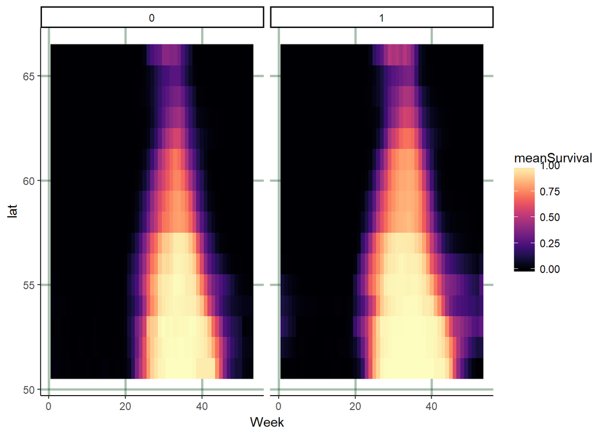

```r
  df_byPeriod %>%
  ggplot(aes(Week, lat, meanSurvival)) + geom_tile(aes(fill = meanSurvival)) +
    theme_classic() +
    theme(legend.direction = "vertical",
        legend.title = element_text('Mean Weekly Survival \n across taxa'),
         panel.grid.major = element_line(size = 1, colour = '#00441155')) +
   # scale_fill_gradient(low="white", high="blue") +
    scale_fill_gradientn(colours = viridis::magma(256)) +
    facet_wrap(~Period)
```